# InVivoStat Graphics

## Selected variables

The variable Resp2 has been selected as the response and the variable Resp 1 has been selected to define the X-axis. The variable Resp2 has been square root transformed. The variable Resp 1 has been square root transformed. The variable Cat1 has been selected as the categorisation factor.

## Categorised scatterplot

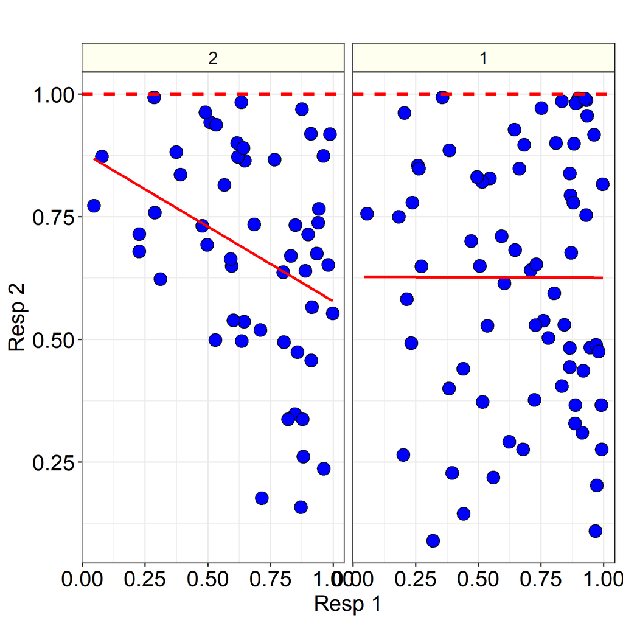

## Pearson's correlation coefficients and p-values

| Categorisation factor levels | Correlation coefficient | p-value |
| --- | --- | --- |
| 1 | -0.002 | 0.9867 |
| 2 | -0.345 | 0.0107 |

## Estimate of the coefficients of the fitted linear lines

| Categorisation factor levels | Intercept estimate | Slope estimate |
| --- | --- | --- |
| 1 | 0.6276 | -0.0020 |
| 2 | 0.8822 | -0.3043 |

For more information on the theoretical approaches that are implemented within this module, see Bate and Clark (2014).

## References

When referring to InVivoStat, please cite 'InVivoStat, version 5.0'.

Bate, S.T. and Clark, R.A. (2014). The Design and Statistical Analysis of Animal Experiments. Cambridge University Press.

#### R references

R Core Team (2022). R: A language and environment for statistical computing. R Foundation for Statistical Computing, Vienna, Austria. URL https://www.R-project.org/.

Lecoutre, Eric (2003). The R2HTML Package. R News, Vol 3. N. 3, Vienna, Austria.

Schloerke B, Cook D, Larmarange J, Briatte F, Marbach M, Thoen E, Elberg A, Crowley J (2023). GGally: Extension to ggplot2. R package version 2.2.0, https://CRAN.R-project.org/package=GGally.

Neuwirth E (2022). RColorBrewer: ColorBrewer Palettes. R package version 1.1-3, https://CRAN.R-project.org/package=RColorBrewer.

H. Wickham. ggplot2: Elegant Graphics for Data Analysis. Springer-Verlag New York, 2016.

Slowikowski K (2024). ggrepel: Automatically Position Non-Overlapping Text Labels with ggplot2. R package version 0.9.5, https://CRAN.R-project.org/package=ggrepel.

H. Wickham. Reshaping data with the reshape package. Journal of Statistical Software, 21(12), 2007.

Hadley Wickham (2011). The Split-Apply-Combine Strategy for Data Analysis. Journal of Statistical Software, 40(1), 1-29. URL https://www.jstatsoft.org/v40/i01/.

Wickham H, Pedersen T, Seidel D (2023). scales: Scale Functions for Visualization. R package version 1.3.0, https://CRAN.R-project.org/package=scales.

Grothendieck G, Kates L, Petzoldt T (2016). proto: Prototype Object-Based Programming. R package version 1.0.0, https://CRAN.R-project.org/package=proto.

## Analysis dataset

| Observation | Resp2 | Resp 1 | Cat1 |
| --- | --- | --- | --- |
| 1 | 0.474 | 0.857 | 2 |
| 2 | 0.348 | 0.847 | 2 |
| 3 | 0.537 | 0.644 | 2 |
| 4 | 0.637 | 0.801 | 2 |
| 5 | 0.457 | 0.912 | 2 |
| 6 | 0.943 | 0.509 | 2 |
| 7 | 0.864 | 0.647 | 2 |
| 8 | 0.733 | 0.849 | 2 |
| 9 | 0.837 | 0.390 | 2 |
| 10 | 0.693 | 0.497 | 2 |
| 11 | 0.566 | 0.914 | 2 |
| 12 | 0.993 | 0.285 | 2 |
| 13 | 0.261 | 0.880 | 2 |
| 14 | 0.237 | 0.962 | 2 |
| 15 | 0.920 | 0.910 | 2 |
| 16 | 0.984 | 0.632 | 2 |
| 17 | 0.938 | 0.532 | 2 |
| 18 | 0.872 | 0.620 | 2 |
| 19 | 0.759 | 0.288 | 2 |
| 20 | 0.520 | 0.709 | 2 |
| 21 | 0.553 | 0.997 | 2 |
| 22 | 0.675 | 0.934 | 2 |
| 23 | 0.867 | 0.766 | 2 |
| 24 | 0.539 | 0.602 | 2 |
| 25 | 0.970 | 0.875 | 2 |
| 26 | 0.735 | 0.685 | 2 |
| 27 | 0.640 | 0.889 | 2 |
| 28 | 0.873 | 0.077 | 2 |
| 29 | 0.875 | 0.961 | 2 |
| 30 | 0.919 | 0.986 | 2 |

[output cut: 96 more lines]

## Analysis options

Response variable: Resp2

Response variable transformation: square root

X-axis variable: Resp 1

X-axis variable transformation: square root

Second categorisation factor: Cat1

Categorised gragh style: separate

Display legend (Y/N): Y

X-axis title (except for Histogram): Resp 1

Y-axis title: Resp 2

Re-ordered 2nd categorisation factor levels: 2,1

Output Scatterplot (Y/N): Y

Include linear fit (Y/N): Y

Reference line included on Case profiles plot: 1